# Analysis of City of Toronto’s “Traffic Volumes - Midblock Vehicle Speed, Volume and Classification Counts” Dataset

## Introduction

This report will use the “Traffic Volumes - Midblock Vehicle Speed, Volume and Classification Counts” Dataset provided by the City of Toronto through the `opendatatoronto` API.

This report will attempt to visualize and interpret various characteristics within traffic volumes and bheaviour within Toronto. Analysis will include:

- examination of continuous variates and their relationships.
- geospatial visualiztion of a traffic volume.
- categorical comparison of traffic volume on weekdays and weekends.
- tabular summary of driving behaviours in regions of interest.

## Loading Traffic Volumes Data

```r
library(opendatatoronto)
library(ggplot2)
library(dplyr)
packages <- search_packages("Traffic Volumes - Midblock Vehicle Speed, Volume and Classification Counts")

package_id <- packages$id[1]
resources <- list_package_resources(package_id)
traffic_data <- get_resource(resources[3,'id'])
```

## Analysis of Road Characteristics and Driving Behaviour

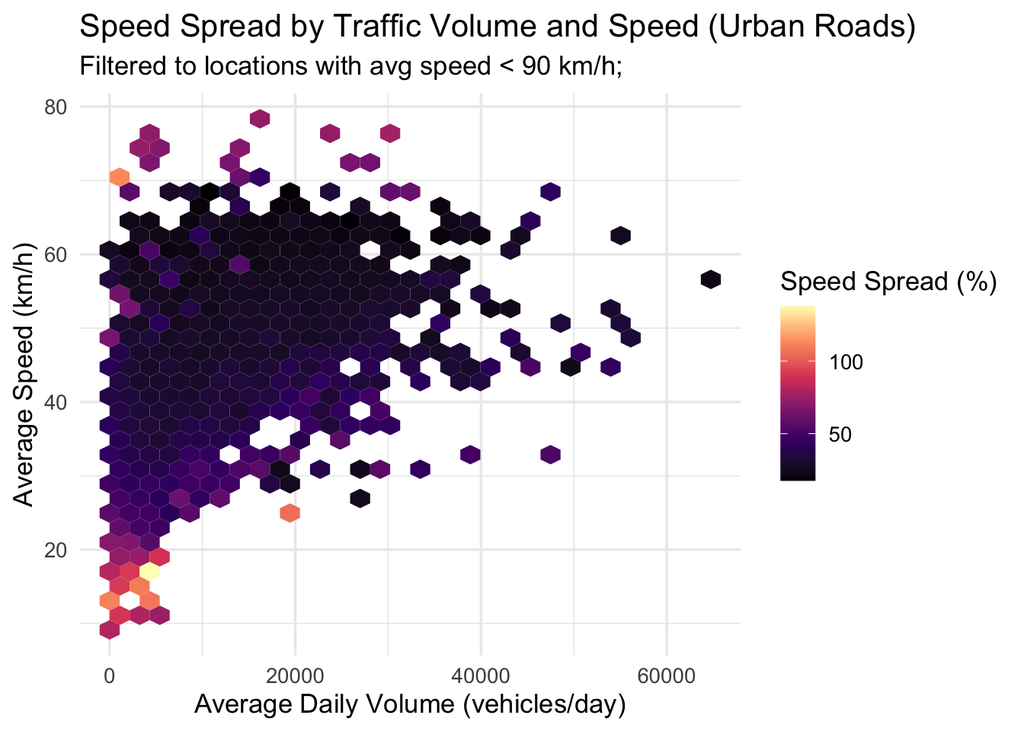

```r
# transforming data:
# add "speed spread" feature
df_filtered <- traffic_data %>%
  mutate(speed_spread = (avg_95th_percentile_speed - avg_speed) * 100 / avg_speed) %>%
# filter for road segments with average speed < 90km/h to analyze urban road segments only
  filter(!is.na(avg_daily_vol), !is.na(avg_speed), !is.na(speed_spread), avg_speed < 90)

# plot: daily volume vs average speed, with color scale = speed spread
ggplot(df_filtered, aes(x = avg_daily_vol, y = avg_speed)) +
  stat_summary_hex(aes(z = speed_spread), bins = 30, fun = mean) +
  scale_fill_viridis_c(option = "magma", name = "Speed Spread (%)") +
  labs(
    title = "Speed Spread by Traffic Volume and Speed (Urban Roads)",
    subtitle = "Filtered to locations with avg speed < 90 km/h;",
    x = "Average Daily Volume (vehicles/day)",
    y = "Average Speed (km/h)"
  ) +
  theme_minimal(base_size = 13)
```

This hexbin plot atempts to visualize how traffic volume and average speed relate to driving behaviour. A driving behaviour of interest was how much faster the speeding drivers were driving compared to an average driver on the same road segment. We have devised a “speed spread” metric for this purpose, which is defined as the percentage difference between the 95th percentile and average speed, across urban roads in Toronto. The analysis focuses on roads with average speeds below 90 km/h to capture non-highway traffic behavior.

Key insights include:

- Low-volume, low-speed segments (<10,000 vehicles/day and <30 km/h) show high speed spread. Suggests greater variance in speed, between speeding driveers and average drivers.
- High-volume roads show consistently low speed spread. We suspect it is likely due to a certain level of congestion that limits vehicle speeds.
- Moderate speed segments (40–60 km/h) also show low speed spread, possibly reflecting well-designed arterial roads with smoother traffic flow.

Overall, driver speed consistency appears strongest on busier roads, while quiet streets may see more varying behavior from a few speeding vehicles.

## Geographical View of High-Volume Traffic Segments in Downtown Toronto

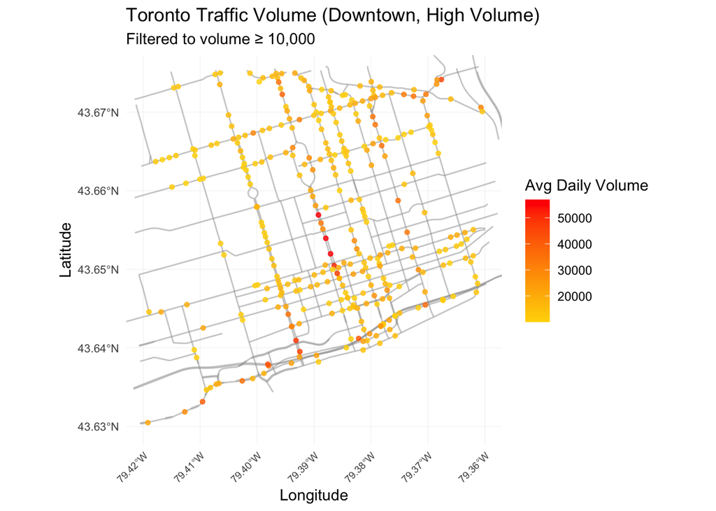

```r
library(ggplot2)
library(dplyr)
library(sf)
library(osmdata)
# bounding box coordinates for downtown Toronto
xmin <- -79.42
xmax <- -79.36
ymin <- 43.630
ymax <- 43.675

# setting up underlying map of Toronto using osmdata
osm_bb <- c(left = xmin, bottom = ymin, right = xmax, top = ymax)

streets <- opq(bbox = osm_bb) %>%
  add_osm_feature(key = "highway", value = c("motorway", "primary", "secondary", "tertiary")) %>%
  osmdata_sf()

# data manipulation: filter for traffic data for downtown + volume ≥ 10,000
traffic_sf <- traffic_data %>%
  filter(
    !is.na(latitude), !is.na(longitude), !is.na(avg_daily_vol),
    longitude >= xmin, longitude <= xmax,
    latitude  >= ymin, latitude  <= ymax,
    avg_daily_vol >= 10000
  ) %>%
  st_as_sf(coords = c("longitude", "latitude"), crs = 4326)

# overlay color-scaled points on to osm map
ggplot() +
  geom_sf(data = streets$osm_lines, color = "gray60", size = 0.2, alpha = 0.5) +
  geom_sf(data = traffic_sf, aes(color = avg_daily_vol), size = 1.2, alpha = 0.8) +
  scale_color_gradient(name = "Avg Daily Volume", low = "gold", high = "red") +
  labs(
    title = "Toronto Traffic Volume (Downtown, High Volume)",
    subtitle = "Filtered to volume ≥ 10,000",
    x = "Longitude", y = "Latitude"
  ) +
  coord_sf(xlim = c(xmin, xmax), ylim = c(ymin, ymax)) +
  theme_minimal() +
theme(
  panel.grid.major = element_line(color = "gray90", size = 0.1),
  axis.text.x = element_text(angle = 45, hjust = 1, size = 7),
  axis.text.y = element_text(size = 8)
)
```

This map shows high-traffic road segments in downtown Toronto, plotted over a map of Toronto found on OpenStreetMap framework. Each point plots a traffic monitoring location, color-scaled by average daily volume (yellow to red).

The dataset used in the map has been filtered to include only the segments within a defined downtown boundary (longitude and latitude coordinates) suggested by a Google search, and with daily volume of at least 10,000 vehicles. This highlights key corridors in the location of interest (Downtown Toronto) and removes noise from minor roads.

Key Insights include:

- The highest traffic zones are center of downtown near Union Station and Bay Street, which are major downtown regions, as expected.
- Outer downtown roads also exceed 10,000 vehicles/day but see less intensity.
- Map suggests there are higher volumes spotted on vertical road segments like University Ave. than horizontal road segments.

Overall, this spatial view highlights congestion hotspots and may be useful in selecting regions for further traffic planning, enforcement, and infrastructure upgrades.

## Traffic Volume Differences Between Weekdays and Weekends

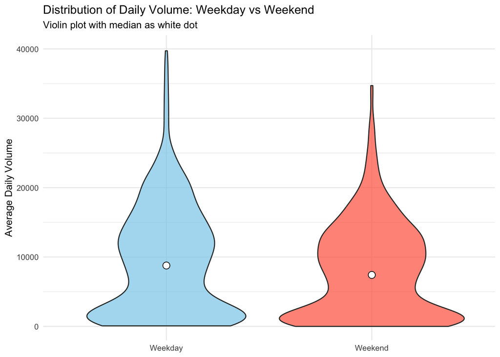

```r
# Load libraries
library(dplyr)
library(tidyr)
library(ggplot2)
library(scales)

# filter comparable segments with both weekday and weekend observations
df_wdy_wknd <- traffic_data %>%
  filter(
    !is.na(avg_weekday_daily_vol),
    !is.na(avg_weekend_daily_vol)
  )

# long format
df_long <- df_wdy_wknd %>%
  select(centreline_id, avg_weekday_daily_vol, avg_weekend_daily_vol) %>%
  filter(
    avg_weekday_daily_vol <= 40000,
    avg_weekend_daily_vol <= 40000
    ) %>%
  pivot_longer(
    cols = c(avg_weekday_daily_vol, avg_weekend_daily_vol),
    names_to = "day_type",
    values_to = "volume"
  ) %>%
  mutate(
    day_type = recode(day_type,
                      avg_weekday_daily_vol = "Weekday",
                      avg_weekend_daily_vol = "Weekend"),
    day_type = factor(day_type, levels = c("Weekday", "Weekend"))
  )

# side by side boxplot
ggplot(df_long, aes(x = day_type, y = volume, fill = day_type)) +
  geom_violin(trim = TRUE, alpha = 0.7) +
  stat_summary(fun = median, geom = "point", shape = 21, fill = "white", size = 3) +
  coord_cartesian(ylim = c(0, 40000)) +
  scale_fill_manual(values = c("skyblue", "tomato")) +
  labs(
    title = "Distribution of Daily Volume: Weekday vs Weekend",
    subtitle = "Violin plot with median as white dot",
    x = NULL,
    y = "Average Daily Volume"
  ) +
  theme_minimal(base_size = 10) +
  theme(legend.position = "none")
```

This violin plot compares the distribution of average daily traffic volume between weekdays and weekends across monitored road segments in Toronto. Only segments with data for both day types are included. To remove the influence of extreme values, segments with average volumes above 40,000 vehicles/day were excluded. Which resulted in removal of 2-3 values for each category.

Each violin illustrates the shape of the distribution, with the white dot marking the median.

Key Insights:

Weekday traffic volumes appear to be slightly more dispersed and skewed toward higher values due to workday commuting, while weekend traffic appears more stable and centered across road segments. That being said, both distributions appear to be extremely similar, excluding outliers, which is as expected as busy road segments on weekdays will likely be busy on weekends as well.

## Top 10 Segments by Speed Spread Conditioned by Location

```r
library(dplyr)
library(gt)
library(scales)

downtown_bb <- list(lon_min = -79.42, lon_max = -79.36, lat_min = 43.63, lat_max = 43.675)

    df_top10_speed <- traffic_data %>%
      filter(!is.na(location_name), !is.na(avg_daily_vol), !is.na(avg_speed),
             !is.na(avg_95th_percentile_speed), !is.na(latitude), !is.na(longitude), avg_speed > 0) %>%
      mutate(speed_spread = (avg_95th_percentile_speed - avg_speed) * 100 / avg_speed,
             flag = ifelse(latitude >= downtown_bb$lat_min & latitude <= downtown_bb$lat_max &
                             longitude >= downtown_bb$lon_min & longitude <= downtown_bb$lon_max,
                           "Downtown", "Non-Downtown")) %>%
      select(location_name, speed_spread, avg_daily_vol, flag) %>%
      arrange(desc(speed_spread)) %>%
      slice(1:10)

    df_top10_speed %>%
      gt() %>%
      tab_header(
        title = "Top 10 Segments with Highest Speed Spread",
        subtitle = "Downtown or Non-downtown: conditioned on coordinates "
      ) %>%
      fmt_number(columns = c(speed_spread), decimals = 1) %>%
      fmt_number(columns = c(avg_daily_vol), sep_mark = ",", decimals = 0) %>%
      data_color(columns = c(speed_spread), colors = col_numeric(palette = c("orange", "red"), domain = NULL)) %>%
      data_color(columns = c(avg_daily_vol), colors = col_numeric(palette = c("lightblue", "blue"), domain = NULL)) %>%
      cols_label(location_name = "Road Segment", speed_spread = "Speed Spread (%)", avg_daily_vol = "Avg Daily Volume", flag = "Downtown") %>%
      tab_style(style = list(cell_fill(color = "lightgreen"), cell_text(weight = "bold", color = "darkgreen")),
                locations = cells_body(columns = c(flag), rows = flag == "Downtown"))
```

Top 10 Segments with Highest Speed Spread

Downtown or Non-downtown: conditioned on coordinates

| Road Segment | Speed Spread (%) | Avg Daily Volume | Downtown |
| --- | --- | --- | --- |
| Ln S College W Margueretta: Margueretta St - Ln E St Clarens S College | 280.5 | 9 | Non-Downtown |
| Robin Fraser Lane: Rebellion Lane - Cottingham St | 251.8 | 30 | Non-Downtown |
| Ln W Bathurst N Dewbourne: Dewbourne Ave - Ln S Eglinton E Peveril | 241.7 | 180 | Non-Downtown |
| McGlashan Rd: McGlashan Crt - Mason Blvd | 234.9 | 574 | Non-Downtown |
| Ln W Sorauren S Marion: Marion St - Ln W Callender N Harvard | 228.5 | 60 | Non-Downtown |
| Yorkminster Rd: Ln W Fairmeadow N Yorkminster - Fairmeadow Ave | 209.4 | 584 | Non-Downtown |
| Wellesworth Dr: Faversham Cres - Clumber Rd | 196.3 | 4,063 | Non-Downtown |
| Scott Rd: Trowell Ave - Ewart Ave | 185.5 | 13 | Non-Downtown |
| Drexel Rd: Brucewood Cres - Prince Charles Dr | 181.9 | 146 | Non-Downtown |
| Meadow Lane Ave: Haymarket Rd - Jethro Rd | 180.5 | 55 | Non-Downtown |

This table displays the top 10 Toronto road segments in terms of highest speed spread, which is defined to be the percent difference between the 95th percentile and average speeds. The speed spread is used as a metric for extreme or inconsistent driver behavior on a particular road segment. Segments are also conditioned on location and flagged as “Downtown” or “Non-Downtown” based on coordinate boundaries defined in previous analysis.

Surprisingly, all top 10 segments are located outside downtown, presumably in extremly low-volume residential areas. The highest spread, over 280%, occurred on a segment averaging just 9 vehicles/day.

Table suggests that suburban streets, not downtown roads, may be most vulnerable to dangerous speeding and these potentially secluded areas may benefit from targeted traffic calming or enforcement.